# Experiments with groups of stations: catchment size

FBK

9 januar 2017

## QS

[1] “QS” [1] 2 [1] 1 19 27 30 32 33 38 45 54 56 57 58 59 63 65 66 67 [18] 68 81 88 91 92 94 96 97 101 102 103 106 109 110 111 116 117 [35] 121 122 124 126 127 128 129 139 141 144 146 147 149 151 156 161 164 [52] 165 171 186 192 203 204 205 214 220 224 225 226 227 228 238 251 268 [69] 270 278 291 302 [1] “done printint”

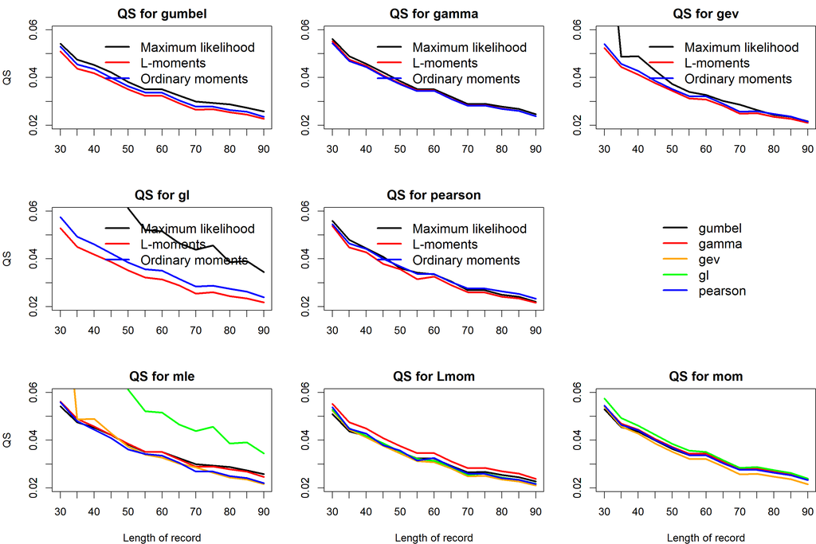

[1] “QS” [1] 2 [1] 2 20 25 28 39 41 46 47 48 49 50 55 60 61 64 69 75 [18] 77 80 82 83 84 86 93 95 99 105 108 119 123 125 132 133 136 [35] 138 148 157 158 160 163 169 179 182 185 197 201 202 211 213 216 217 [52] 219 222 229 231 233 245 246 247 256 262 263 271 273 279 282 283 288 [69] 289 290 298 [1] “done printint”

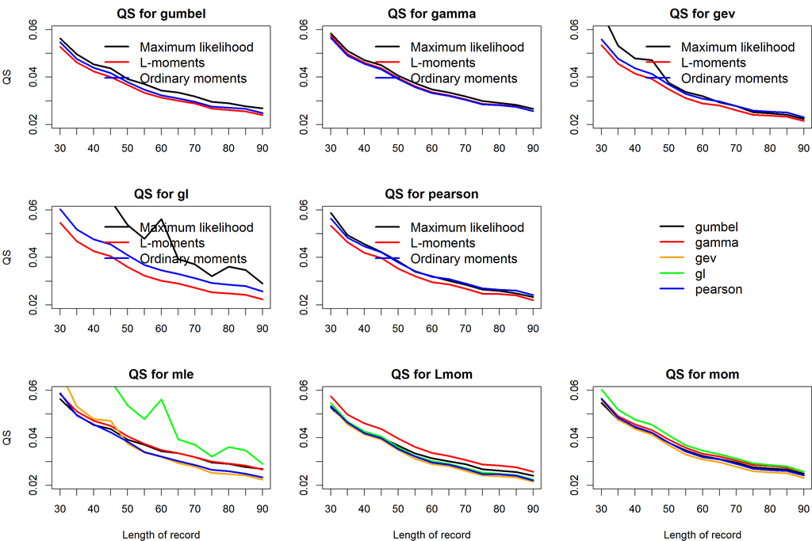

[1] “QS” [1] 2 [1] 6 13 14 15 16 17 18 22 23 29 31 40 42 43 62 70 73 [18] 74 76 87 98 100 112 113 120 130 134 135 137 142 143 145 150 152 [35] 153 172 174 176 177 178 181 183 194 199 200 207 208 212 215 218 221 [52] 235 237 239 241 242 243 252 254 255 257 260 274 275 276 277 280 281 [69] 285 287 300 [1] “done printint”

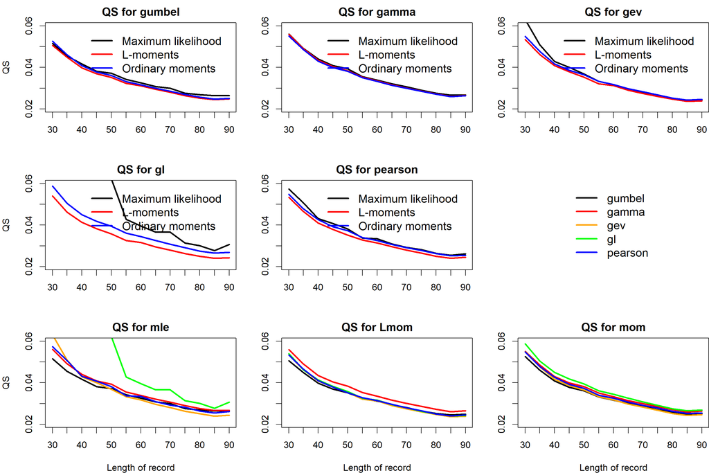

[1] “QS” [1] 2 [1] 3 4 5 7 8 9 10 11 12 21 24 26 35 36 37 44 51 [18] 52 53 71 72 78 79 85 89 90 104 107 114 115 118 131 154 155 [35] 159 162 166 167 168 170 173 180 187 188 189 190 191 195 196 198 209 [52] 223 230 234 236 240 244 249 253 258 259 261 264 269 272 292 293 295 [69] 303 304 305 306 [1] “done printint”

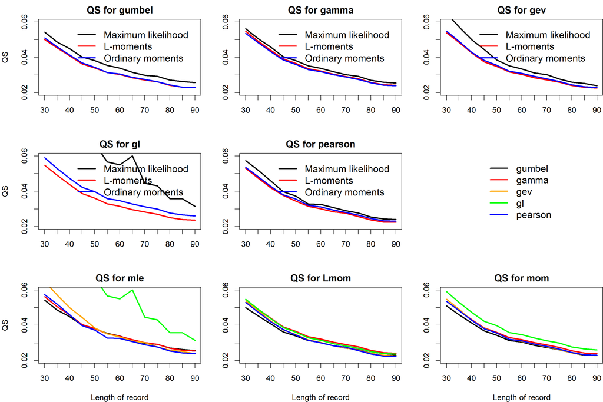

## BS

[1] “BS” [1] 2 [1] 1 19 27 30 32 33 38 45 54 56 57 58 59 63 65 66 67 [18] 68 81 88 91 92 94 96 97 101 102 103 106 109 110 111 116 117 [35] 121 122 124 126 127 128 129 139 141 144 146 147 149 151 156 161 164 [52] 165 171 186 192 203 204 205 214 220 224 225 226 227 228 238 251 268 [69] 270 278 291 302 [1] “done printint”

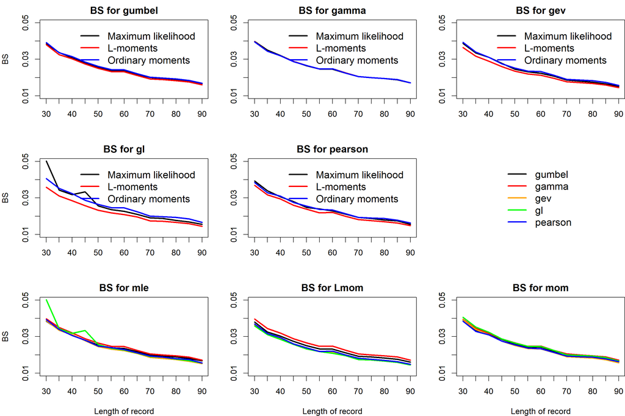

[1] “BS” [1] 2 [1] 2 20 25 28 39 41 46 47 48 49 50 55 60 61 64 69 75 [18] 77 80 82 83 84 86 93 95 99 105 108 119 123 125 132 133 136 [35] 138 148 157 158 160 163 169 179 182 185 197 201 202 211 213 216 217 [52] 219 222 229 231 233 245 246 247 256 262 263 271 273 279 282 283 288 [69] 289 290 298 [1] “done printint”

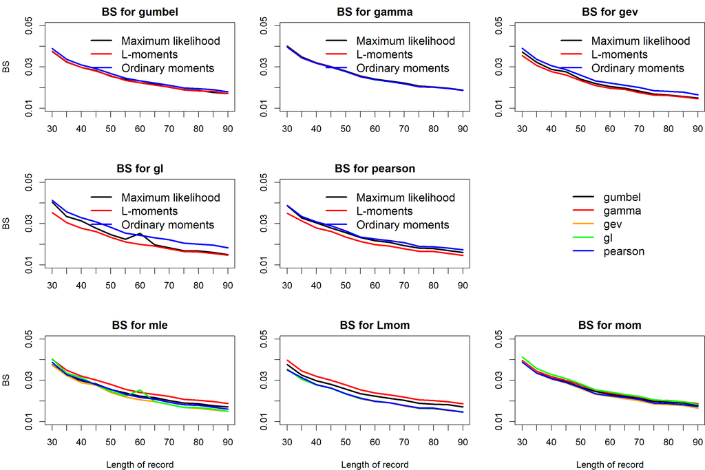

[1] “BS” [1] 2 [1] 6 13 14 15 16 17 18 22 23 29 31 40 42 43 62 70 73 [18] 74 76 87 98 100 112 113 120 130 134 135 137 142 143 145 150 152 [35] 153 172 174 176 177 178 181 183 194 199 200 207 208 212 215 218 221 [52] 235 237 239 241 242 243 252 254 255 257 260 274 275 276 277 280 281 [69] 285 287 300 [1] “done printint”

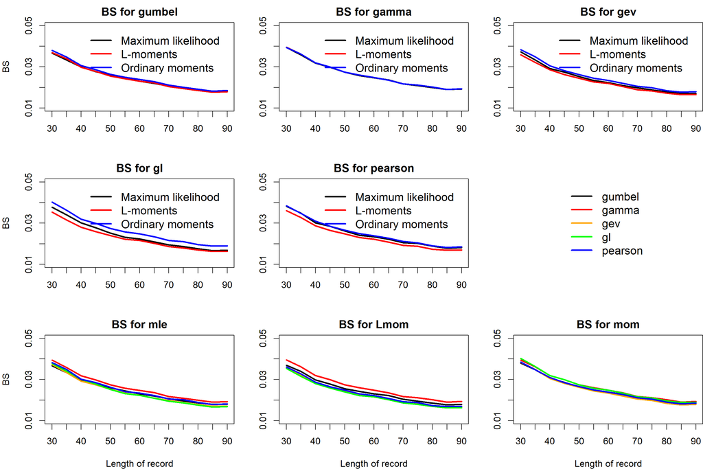

[1] “BS” [1] 2 [1] 3 4 5 7 8 9 10 11 12 21 24 26 35 36 37 44 51 [18] 52 53 71 72 78 79 85 89 90 104 107 114 115 118 131 154 155 [35] 159 162 166 167 168 170 173 180 187 188 189 190 191 195 196 198 209 [52] 223 230 234 236 240 244 249 253 258 259 261 264 269 272 292 293 295 [69] 303 304 305 306 [1] “done printint”

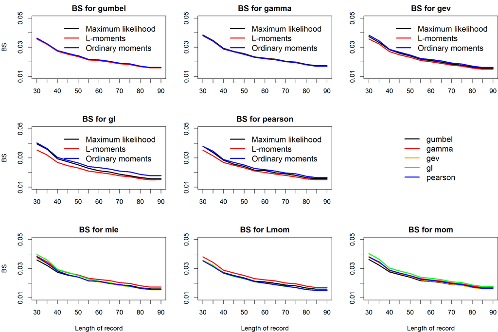

## Return levels

#### RL 10y

[1] “r.levels” [1] 10 [1] 1 19 27 30 32 33 38 45 54 56 57 58 59 63 65 66 67 [18] 68 81 88 91 92 94 96 97 101 102 103 106 109 110 111 116 117 [35] 121 122 124 126 127 128 129 139 141 144 146 147 149 151 156 161 164 [52] 165 171 186 192 203 204 205 214 220 224 225 226 227 228 238 251 268 [69] 270 278 291 302 [1] “done printint”

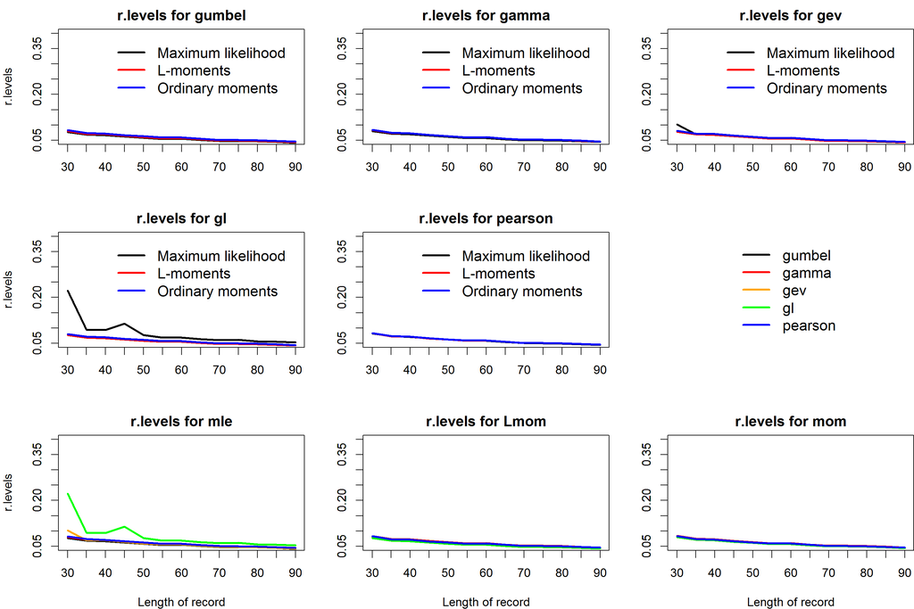

[1] “r.levels” [1] 10 [1] 2 20 25 28 39 41 46 47 48 49 50 55 60 61 64 69 75 [18] 77 80 82 83 84 86 93 95 99 105 108 119 123 125 132 133 136 [35] 138 148 157 158 160 163 169 179 182 185 197 201 202 211 213 216 217 [52] 219 222 229 231 233 245 246 247 256 262 263 271 273 279 282 283 288 [69] 289 290 298 [1] “done printint”

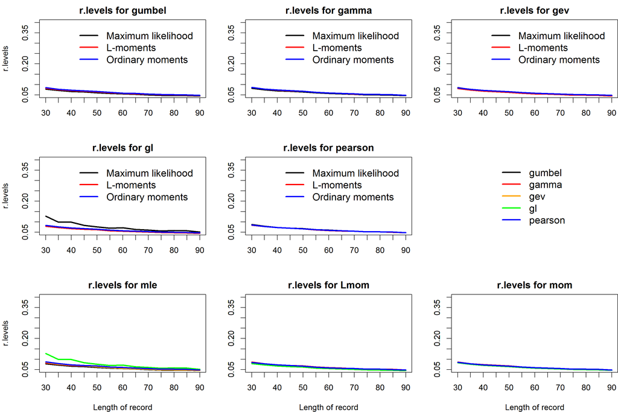

[1] “r.levels” [1] 10 [1] 6 13 14 15 16 17 18 22 23 29 31 40 42 43 62 70 73 [18] 74 76 87 98 100 112 113 120 130 134 135 137 142 143 145 150 152 [35] 153 172 174 176 177 178 181 183 194 199 200 207 208 212 215 218 221 [52] 235 237 239 241 242 243 252 254 255 257 260 274 275 276 277 280 281 [69] 285 287 300 [1] “done printint”

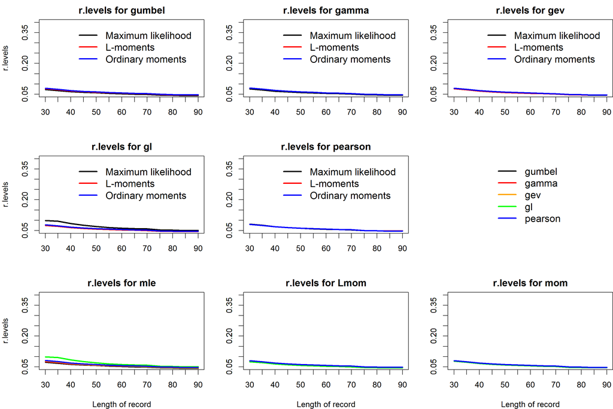

[1] “r.levels” [1] 10 [1] 3 4 5 7 8 9 10 11 12 21 24 26 35 36 37 44 51 [18] 52 53 71 72 78 79 85 89 90 104 107 114 115 118 131 154 155 [35] 159 162 166 167 168 170 173 180 187 188 189 190 191 195 196 198 209 [52] 223 230 234 236 240 244 249 253 258 259 261 264 269 272 292 293 295 [69] 303 304 305 306 [1] “done printint”

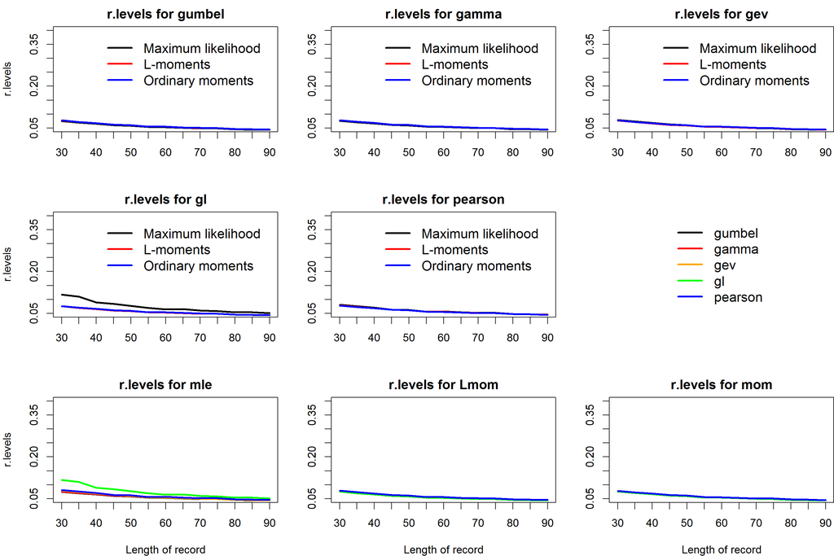

#### RL 100y

[1] “r.levels” [1] 100 [1] 1 19 27 30 32 33 38 45 54 56 57 58 59 63 65 66 67 [18] 68 81 88 91 92 94 96 97 101 102 103 106 109 110 111 116 117 [35] 121 122 124 126 127 128 129 139 141 144 146 147 149 151 156 161 164 [52] 165 171 186 192 203 204 205 214 220 224 225 226 227 228 238 251 268 [69] 270 278 291 302 [1] “done printint”

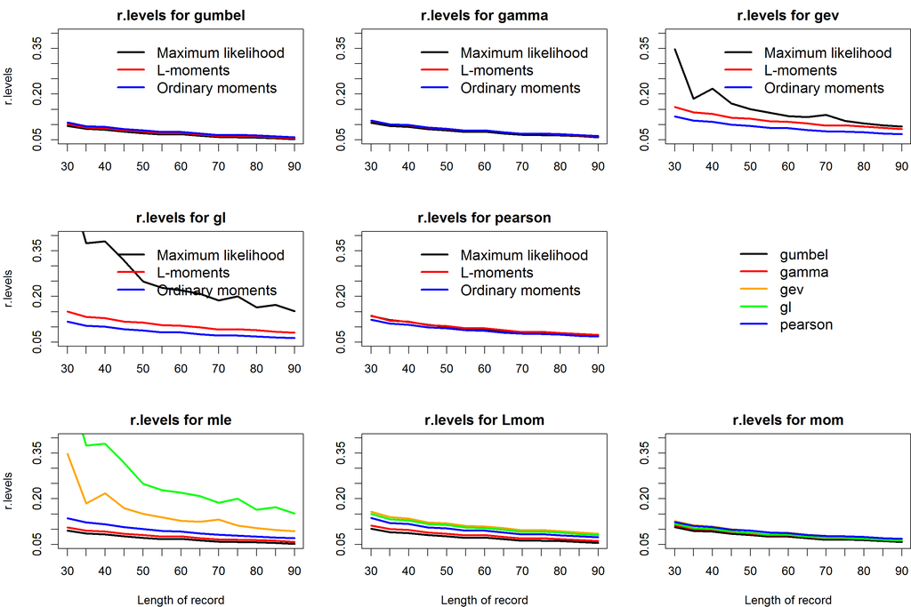

[1] “r.levels” [1] 100 [1] 2 20 25 28 39 41 46 47 48 49 50 55 60 61 64 69 75 [18] 77 80 82 83 84 86 93 95 99 105 108 119 123 125 132 133 136 [35] 138 148 157 158 160 163 169 179 182 185 197 201 202 211 213 216 217 [52] 219 222 229 231 233 245 246 247 256 262 263 271 273 279 282 283 288 [69] 289 290 298 [1] “done printint”

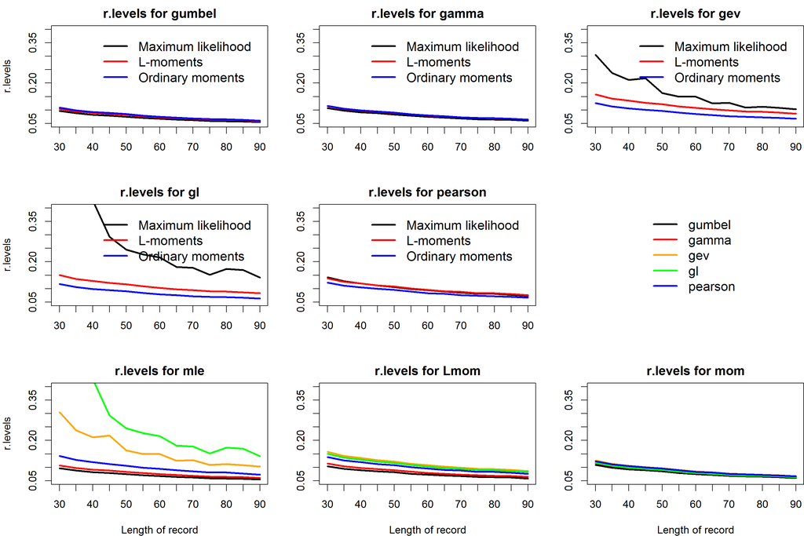

[1] “r.levels” [1] 100 [1] 6 13 14 15 16 17 18 22 23 29 31 40 42 43 62 70 73 [18] 74 76 87 98 100 112 113 120 130 134 135 137 142 143 145 150 152 [35] 153 172 174 176 177 178 181 183 194 199 200 207 208 212 215 218 221 [52] 235 237 239 241 242 243 252 254 255 257 260 274 275 276 277 280 281 [69] 285 287 300 [1] “done printint”

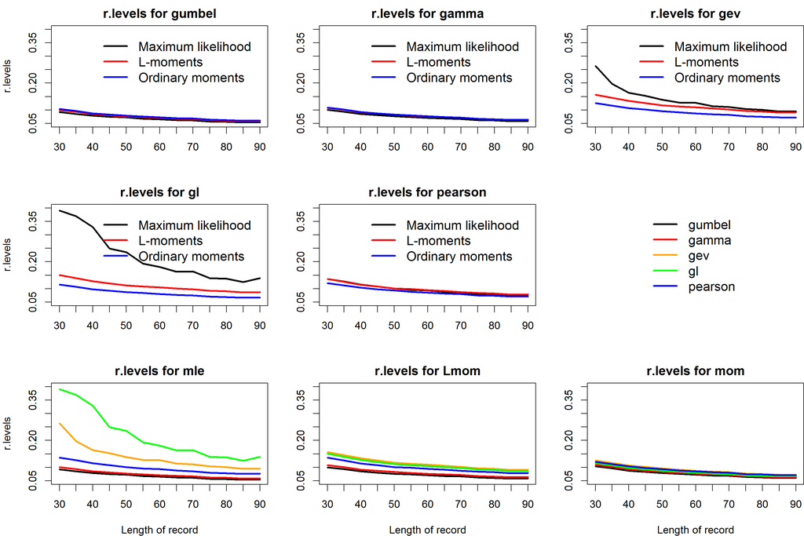

[1] “r.levels” [1] 100 [1] 3 4 5 7 8 9 10 11 12 21 24 26 35 36 37 44 51 [18] 52 53 71 72 78 79 85 89 90 104 107 114 115 118 131 154 155 [35] 159 162 166 167 168 170 173 180 187 188 189 190 191 195 196 198 209 [52] 223 230 234 236 240 244 249 253 258 259 261 264 269 272 292 293 295 [69] 303 304 305 306 [1] “done printint”

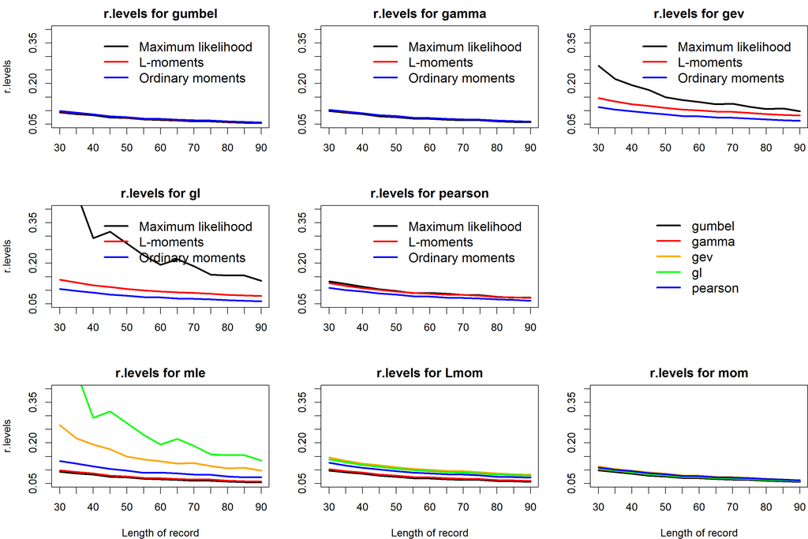

#### RL 200y

[1] “r.levels” [1] 200 [1] 1 19 27 30 32 33 38 45 54 56 57 58 59 63 65 66 67 [18] 68 81 88 91 92 94 96 97 101 102 103 106 109 110 111 116 117 [35] 121 122 124 126 127 128 129 139 141 144 146 147 149 151 156 161 164 [52] 165 171 186 192 203 204 205 214 220 224 225 226 227 228 238 251 268 [69] 270 278 291 302 [1] “done printint”

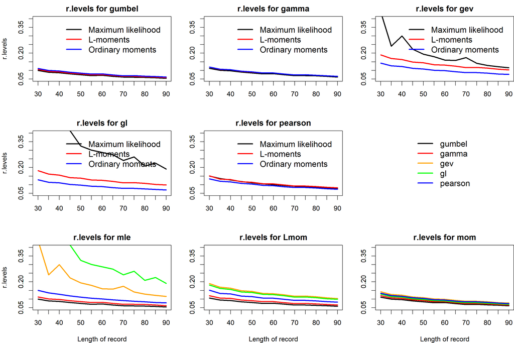

[1] “r.levels” [1] 200 [1] 2 20 25 28 39 41 46 47 48 49 50 55 60 61 64 69 75 [18] 77 80 82 83 84 86 93 95 99 105 108 119 123 125 132 133 136 [35] 138 148 157 158 160 163 169 179 182 185 197 201 202 211 213 216 217 [52] 219 222 229 231 233 245 246 247 256 262 263 271 273 279 282 283 288 [69] 289 290 298 [1] “done printint”

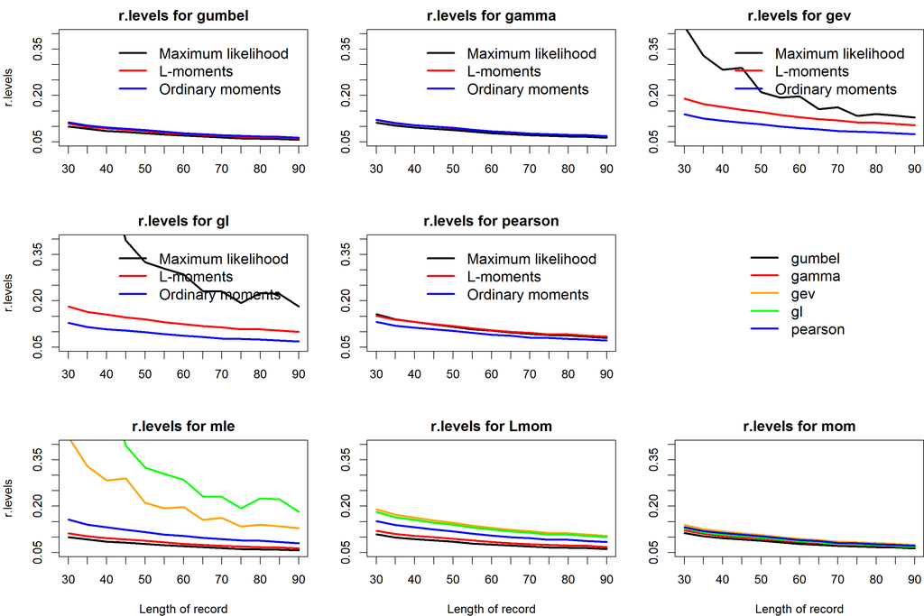

[1] “r.levels” [1] 200 [1] 6 13 14 15 16 17 18 22 23 29 31 40 42 43 62 70 73 [18] 74 76 87 98 100 112 113 120 130 134 135 137 142 143 145 150 152 [35] 153 172 174 176 177 178 181 183 194 199 200 207 208 212 215 218 221 [52] 235 237 239 241 242 243 252 254 255 257 260 274 275 276 277 280 281 [69] 285 287 300 [1] “done printint”

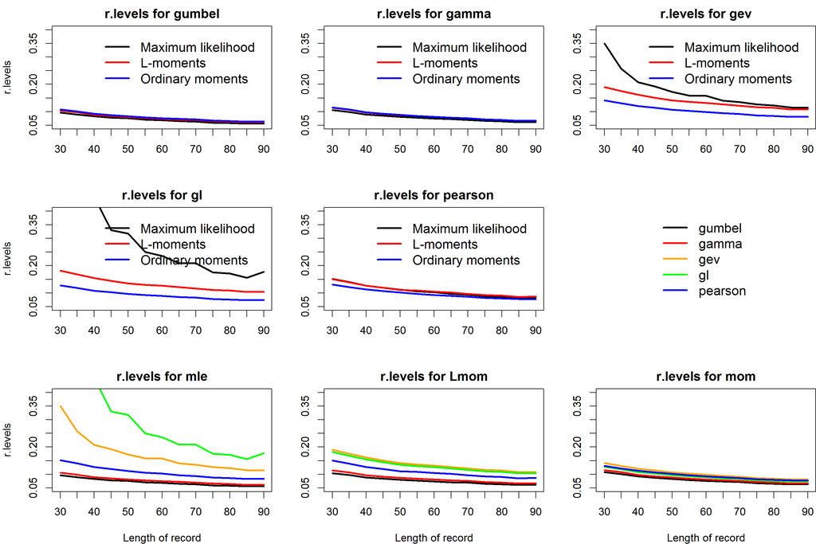

[1] “r.levels” [1] 200 [1] 3 4 5 7 8 9 10 11 12 21 24 26 35 36 37 44 51 [18] 52 53 71 72 78 79 85 89 90 104 107 114 115 118 131 154 155 [35] 159 162 166 167 168 170 173 180 187 188 189 190 191 195 196 198 209 [52] 223 230 234 236 240 244 249 253 258 259 261 264 269 272 292 293 295 [69] 303 304 305 306 [1] “done printint”

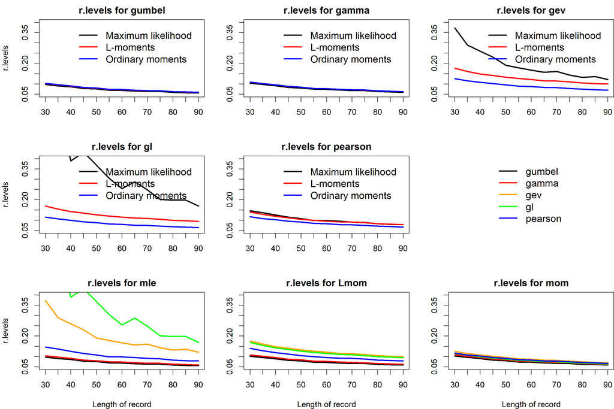

## KS

[1] 1 19 27 30 32 33 38 45 54 56 57 58 59 63 65 66 67 [18] 68 81 88 91 92 94 96 97 101 102 103 106 109 110 111 116 117 [35] 121 122 124 126 127 128 129 139 141 144 146 147 149 151 156 161 164 [52] 165 171 186 192 203 204 205 214 220 224 225 226 227 228 238 251 268 [69] 270 278 291 302 [1] “entered the plotting function” [1] 30 [1] 150

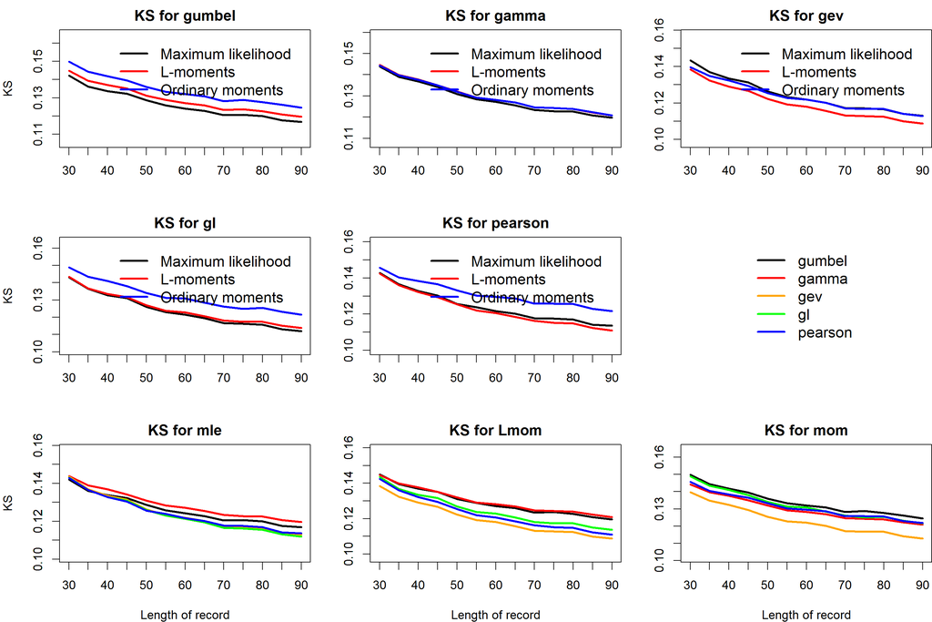

[1] 2 20 25 28 39 41 46 47 48 49 50 55 60 61 64 69 75 [18] 77 80 82 83 84 86 93 95 99 105 108 119 123 125 132 133 136 [35] 138 148 157 158 160 163 169 179 182 185 197 201 202 211 213 216 217 [52] 219 222 229 231 233 245 246 247 256 262 263 271 273 279 282 283 288 [69] 289 290 298 [1] “entered the plotting function” [1] 30 [1] 150

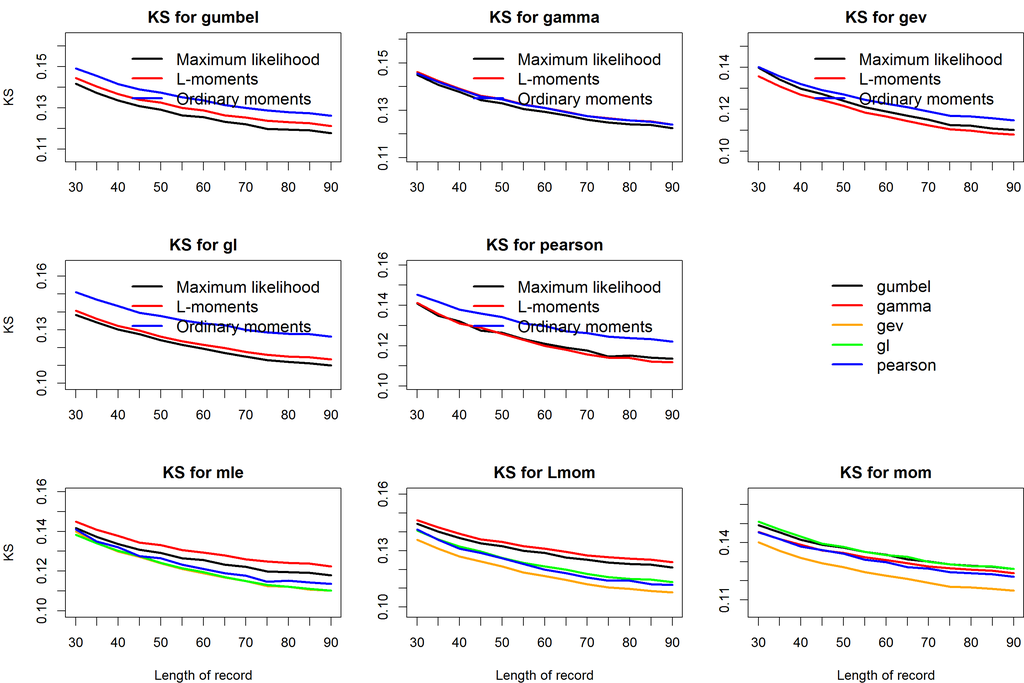

[1] 6 13 14 15 16 17 18 22 23 29 31 40 42 43 62 70 73 [18] 74 76 87 98 100 112 113 120 130 134 135 137 142 143 145 150 152 [35] 153 172 174 176 177 178 181 183 194 199 200 207 208 212 215 218 221 [52] 235 237 239 241 242 243 252 254 255 257 260 274 275 276 277 280 281 [69] 285 287 300 [1] “entered the plotting function” [1] 30 [1] 150

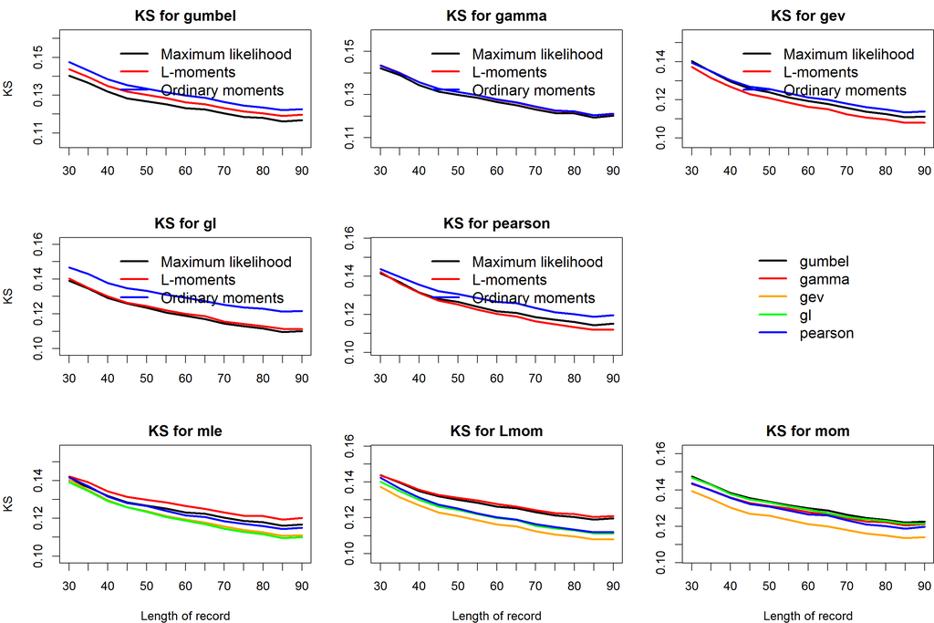

[1] 3 4 5 7 8 9 10 11 12 21 24 26 35 36 37 44 51 [18] 52 53 71 72 78 79 85 89 90 104 107 114 115 118 131 154 155 [35] 159 162 166 167 168 170 173 180 187 188 189 190 191 195 196 198 209 [52] 223 230 234 236 240 244 249 253 258 259 261 264 269 272 292 293 295 [69] 303 304 305 306 [1] “entered the plotting function” [1] 30 [1] 150

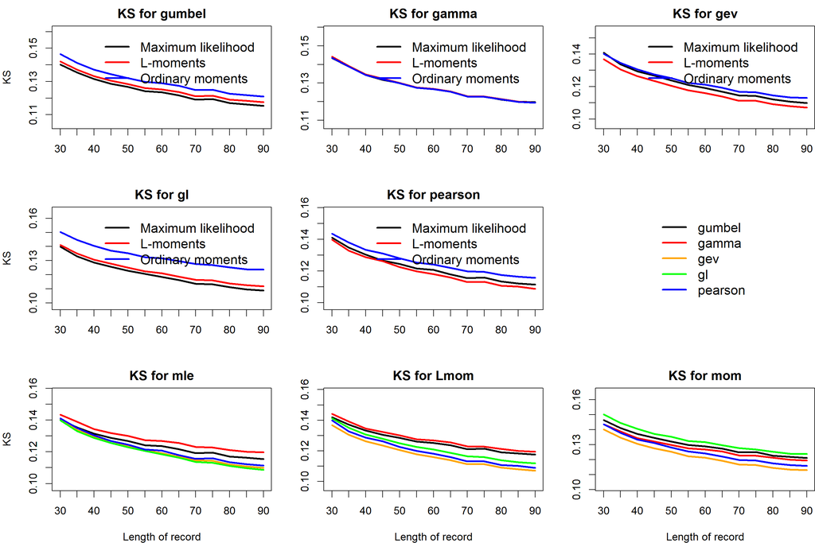

## AD

[1] 1 19 27 30 32 33 38 45 54 56 57 58 59 63 65 66 67 [18] 68 81 88 91 92 94 96 97 101 102 103 106 109 110 111 116 117 [35] 121 122 124 126 127 128 129 139 141 144 146 147 149 151 156 161 164 [52] 165 171 186 192 203 204 205 214 220 224 225 226 227 228 238 251 268 [69] 270 278 291 302 [1] “entered the plotting function” [1] 30 [1] 150

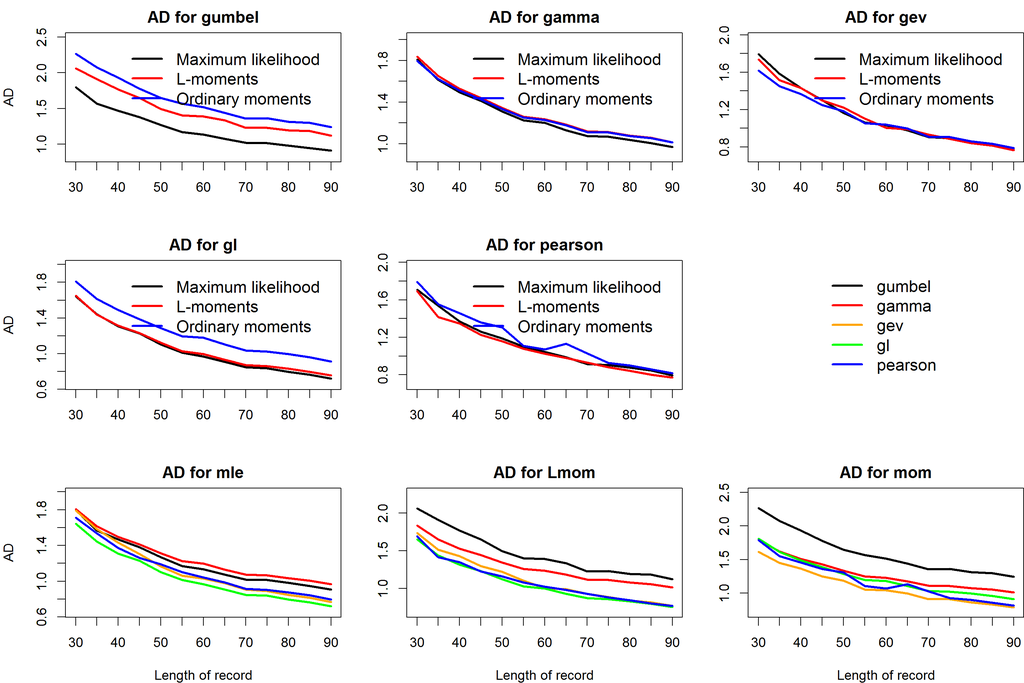

[1] 2 20 25 28 39 41 46 47 48 49 50 55 60 61 64 69 75 [18] 77 80 82 83 84 86 93 95 99 105 108 119 123 125 132 133 136 [35] 138 148 157 158 160 163 169 179 182 185 197 201 202 211 213 216 217 [52] 219 222 229 231 233 245 246 247 256 262 263 271 273 279 282 283 288 [69] 289 290 298 [1] “entered the plotting function” [1] 30 [1] 150

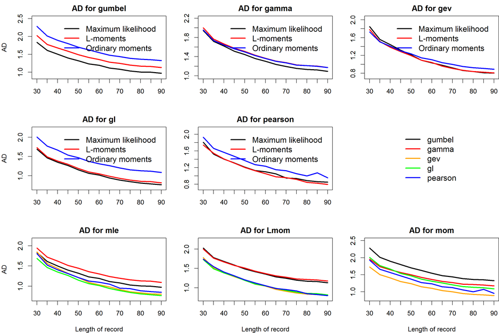

[1] 6 13 14 15 16 17 18 22 23 29 31 40 42 43 62 70 73 [18] 74 76 87 98 100 112 113 120 130 134 135 137 142 143 145 150 152 [35] 153 172 174 176 177 178 181 183 194 199 200 207 208 212 215 218 221 [52] 235 237 239 241 242 243 252 254 255 257 260 274 275 276 277 280 281 [69] 285 287 300 [1] “entered the plotting function” [1] 30 [1] 150

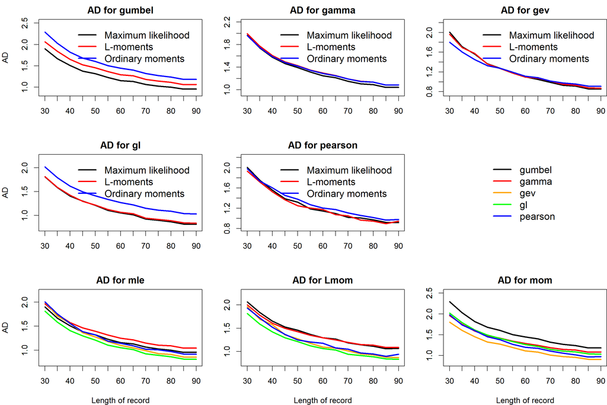

[1] 3 4 5 7 8 9 10 11 12 21 24 26 35 36 37 44 51 [18] 52 53 71 72 78 79 85 89 90 104 107 114 115 118 131 154 155 [35] 159 162 166 167 168 170 173 180 187 188 189 190 191 195 196 198 209 [52] 223 230 234 236 240 244 249 253 258 259 261 264 269 272 292 293 295 [69] 303 304 305 306 [1] “entered the plotting function” [1] 30 [1] 150

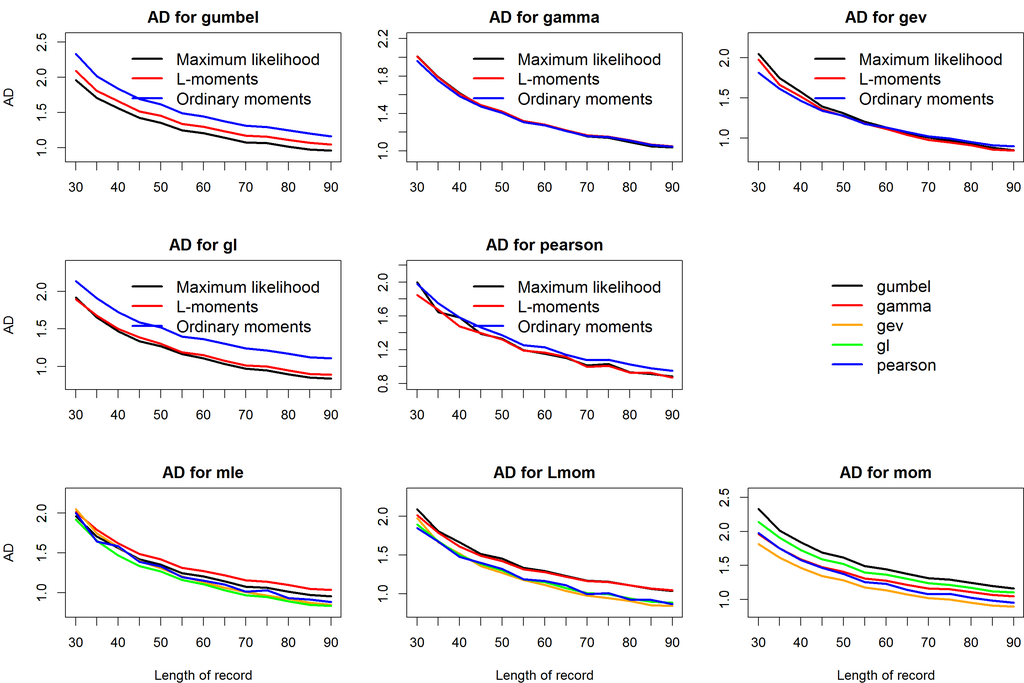